# Estudis d'Informàtica, Multimedia i Telecomunicacions

# M2.959 - PAC2 - Pie Chart

Autor: Carles Sanchez Vilaro

Abril 2025

# 1 Context

Crearem un Pie Chart basat en els accidents de trànsit mortals als EUA durant el 2022 (últim any disponible segons la font), comparant si aquests van tenir lloc a autopistes o en altres vies. El conjunt de dades és de domini públic i ha estat compilat per la National Highway Traffic Safety Administration.

Font: https://static.nhtsa.gov/nhtsa/downloads/FARS/2022/National/FARS2022NationalCSV.zip

# 2 Carrega de dades i llibreries

Carreguem les llibreries necessàries i el conjunt de dades.

```r
llibreries <- c("knitr",
                "dplyr",
                "ggplot2")

llibreries_a_instalar <- llibreries[!(llibreries %in% installed.packages()[,"Package"])]
if(length(llibreries_a_instalar)) install.packages(llibreries_a_instalar)

llibreries_carregades <- lapply(llibreries, library, character.only = TRUE)

accidents <- read.csv("accident.csv")
glimpse(accidents)
```

```
## Rows: 13,047
## Columns: 80
## $ STATE        <int> 1, 1, 1, 1, 1, 1, 1, 1, 1, 1, 1, 1, 1, 1, 1, 1, 1, 1, 1, …
## $ STATENAME    <chr> "Alabama", "Alabama", "Alabama", "Alabama", "Alabama", "A…
## $ ST_CASE      <int> 10001, 10002, 10003, 10004, 10005, 10006, 10007, 10008, 1…
## $ PEDS         <int> 0, 0, 0, 0, 1, 1, 0, 0, 0, 0, 0, 0, 0, 0, 0, 0, 0, 0, 1, …
## $ PERNOTMVIT   <int> 0, 0, 0, 0, 1, 1, 0, 0, 0, 0, 0, 0, 0, 0, 0, 0, 0, 0, 1, …
## $ VE_TOTAL     <int> 2, 2, 1, 1, 1, 1, 2, 1, 2, 1, 1, 2, 2, 2, 1, 1, 1, 1, 1, …
## $ VE_FORMS     <int> 2, 2, 1, 1, 1, 1, 2, 1, 2, 1, 1, 2, 2, 2, 1, 1, 1, 1, 1, …
## $ PVH_INVL     <int> 0, 0, 0, 0, 0, 0, 0, 0, 0, 0, 0, 0, 0, 0, 0, 0, 0, 0, 0, …
## $ PERSONS      <int> 3, 5, 2, 1, 1, 5, 1, 1, 3, 1, 2, 2, 4, 3, 2, 1, 1, 1, 2, …
## $ PERMVIT      <int> 3, 5, 2, 1, 1, 5, 1, 1, 3, 1, 2, 2, 4, 3, 2, 1, 1, 1, 2, …
## $ COUNTY       <int> 107, 101, 115, 101, 73, 101, 63, 101, 71, 131, 115, 125, …
## $ COUNTYNAME   <chr> "PICKENS (107)", "MONTGOMERY (101)", "ST. CLAIR (115)", "…
## $ CITY         <int> 0, 0, 0, 0, 0, 2130, 0, 0, 0, 0, 2560, 2260, 2410, 0, 0, …
```

[output cut: 67 more lines]

Descrivim les variables:

**DIMENSIÓ GEOGRÀFICA**

**DIMENSIÓ TEMPORAL**

- **MONTH** mes
- **MONTHNAME** nom de mes
- **YEAR** any
- **DAY** dia
- **DAYNAME** dia repetit
- **DAY_WEEK** dia de la setmana
- **DAY_WEEKNAME** nom de dia de la setmana
- **HOUR** hora
- **HOURNAME** franja hora
- **MINUTE** minut int
- **MINUTENAME** minut chr

**DIMENSIÓ CONDICIONS ACCIDENT**

- **ST_CASE** identificador d’accident
- **HARM_EV** codi primer esdeveniment de l’accident que produeixi danys o lesions
- **HARM_EVNAME** primer esdeveniment de l’accident que produeixi danys o lesions
- **MAN_COLL** codi de posició dels vehicles
- **MAN_COLLNAME** posició dels vehicles
- **RELJCT1** codi si hi ha àrea d’intercanvi
- **RELJCT1NAME** si hi ha àrea d’intercanvi
- **RELJCT2** codi proximitat encreuament
- **RELJCT2NAME** proximitat encreuament
- **TYP_INT** codi tipus d’intersecció
- **TYP_INTNAME** tipus d’intersecció
- **WRK_ZONE** codi tipologia d’obres
- **WRK_ZONENAME** tipologia d’obres
- **REL_ROAD** codi ubicació vehicle a la via
- **REL_ROADNAME** ubicació vehicle a la via
- **LGT_COND** codi condició lumínica
- **LGT_CONDNAME** condició lumínica
- **DRUNK_DR** conductors beguts
- **VE_TOTAL** nombre de vehicles implicats en total
- **VE_FORMS** nombre de vehicles en moviment implicats
- **PVH_INVL** nombre de vehicles estacionats implicats
- **PEDS** nombre de vianants implicats
- **PERSONS** nombre ocupants de vehicle implicats
- **PERMVIT** nombre conductors i ocupants implicats
- **PERNOTMVIT** nombre vianants, ciclistes, a cavall… qualsevol cosa menys vehicle motoritzat
- **WEATHER** codi temps
- **WEATHERNAME** descriptor temps
- **FATALS** morts
- **NHS** 1 ha passat a autopista del NHS 0 no
- **NHSNAME** descriptor NHS

**ALTRES**

- **SCH_BUS** codi si vehicle escolar implicat
- **SCH_BUSNAME** vehicle escolar implicat
- **RAIL** codi si dins o a prop pas ferroviari
- **RAILNAME** si dins o a prop pas ferroviari

**DIMENSIÓ SERVEI EMERGENCIES**

- **NOT_HOUR** hora notificació a emergències int
- **NOT_HOURNAME** hora notificació a emergències franja
- **NOT_MIN** minut notificació a emergències int
- **NOT_MINNAME** minut notificació a emergències chr
- **ARR_HOUR** hora arribada emergències int
- **ARR_HOURNAME** hora arribada emergències franja
- **ARR_MIN** minut arribada emergències int
- **ARR_MINNAME** minut arribada emergències franja
- **HOSP_HR** hora arribada hospital int
- **HOSP_HRNAME** hora arribada hospital franja
- **HOSP_MN** minut arribada hospital int
- **HOSP_MNNAME** : minut arribada hospital franja

# 3 Pie Chart

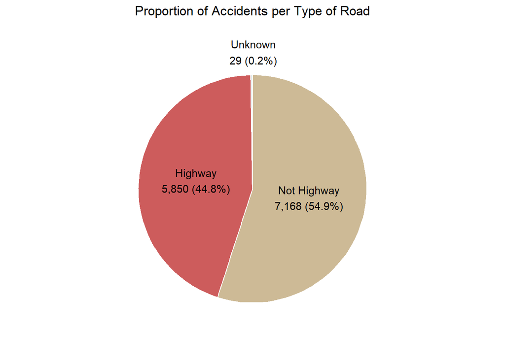

```r
accidents <- accidents %>%
  mutate(NHS = case_when(
    NHS == 0 ~ "Not Highway",
    NHS == 1 ~ "Highway",
    is.na(NHS) | NHS == 9 ~ "Unknown"
  )) %>%
  group_by(NHS) %>%
  summarise(Total_Accidents = n(), .groups = "drop") %>%
  mutate(Percentatge = Total_Accidents / sum(Total_Accidents) * 100)

accidents <- accidents %>%
  arrange(Total_Accidents) %>%
  mutate(
    NHS = factor(NHS, levels = NHS))

ggplot(accidents, aes(x = "", y = Total_Accidents, fill = NHS)) +
  geom_bar(stat = "identity", width = 1, color = "white") +
  coord_polar(theta = "y") +
  theme_void() +
  theme(plot.title = element_text(hjust = 0.5), legend.position = "none") +
  ggtitle("Proportion of Accidents per Type of Road") +
  scale_fill_manual(values = c("Not Highway" = "wheat3",
                               "Highway" = "indianred",
                               "Unknown" = "azure2")) +
  geom_text(aes(
    label = ifelse(Percentatge < 1, "", paste0(NHS, "\n", format(Total_Accidents, big.mark = ","), " (", round(Percentatge, 1), "%)"))
  ), position = position_stack(vjust = 0.5)) +
  geom_text(data = filter(accidents, Percentatge < 1),
            aes(
              x = 1.7, y = cumsum(Total_Accidents) - Total_Accidents / 2,
              label = paste0(NHS, "\n", format(Total_Accidents, big.mark = ","), " (", round(Percentatge, 1), "%)")))
```

# 4 Conclusió

Aquest pie chart mostra la proporció d’accidents segons el tipus de carretera. Una mica més de la meitat d’accidents (54,9%) es produeixen en carreteres que no són autopistes, mentre que un 44,8% tenen lloc en autopistes. Un petit percentatge (0,2%) es classifica com desconegut. Això suggereix que, malgrat les mesures de seguretat a les autopistes, el nombre d’accidents en vies convencionals segueix sent més elevat, possiblement a causa de factors com la presència d’interseccions, vianants i condicions variables del trànsit.